# Customizing Adjusted Survival Curve Plots

Robin Denz

# Introduction

This small vignette gives more details on how the `plot.adjustedsurv()` function may be used to create customized plots of the adjusted survival curves. Currently, this function has over 60 different arguments that can be used to customize the output, so it’s very flexible. Not all arguments will be covered here, but the vignette may help the user to obtain a better understanding of the supported functionality.

# Example Data

To illustrate the different customization options we will use some simulated data, which can be created easily using the `sim_confounded_surv()` function included in this package.

```r
library(ggplot2)
library(adjustedCurves)

set.seed(42)

data <- sim_confounded_surv(n=250, max_t=1.3)
data$group <- as.factor(data$group)
```

We will use an inverse probability of treatment weighted Kaplan-Meier estimator here to obtain the adjusted survival curves:

```r
s_iptw <- adjustedsurv(data=data,
                       variable="group",
                       ev_time="time",
                       event="event",
                       method="iptw_km",
                       treatment_model=group ~ x1 + x3 + x5 + x6,
                       weight_method="glm",
                       conf_int=TRUE,
                       stabilize=TRUE)
```

Note that in a real data analysis, it would be necessary to carefully check the underlying assumptions and to assess whether the chosen weighting method results in reasonable confounder balance between the groups. We also use `stabilize=TRUE` here to ensure that the sum of the weights equals the sample size, which makes the use of risk tables easier.

Calling the `plot()` function on this `adjustedsurv` object without any argument results in the following plot:

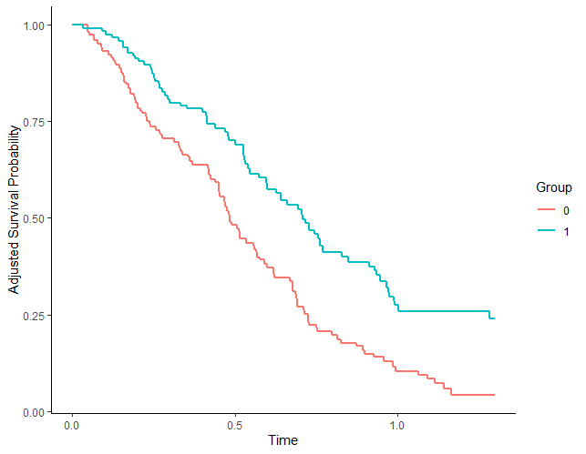

```r
plot(s_iptw)
```

This is already fairly decent, but it could be made much more informative as illustrated below.

# General Plot Aesthetics

To visually distinguish the survival curves, different colors are used by default. By changing the `linetype` and `color` arguments, it is however also possible to use black and white plots instead:

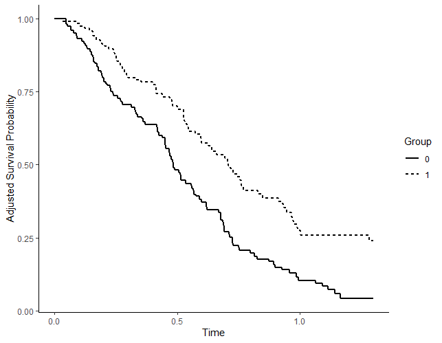

```r
plot(s_iptw, linetype=TRUE, color=FALSE)
```

If colors should be used, it may be usefull to change the colors using the `custom_colors` argument:

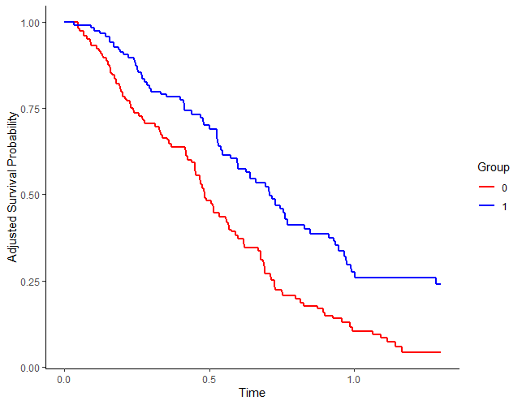

```r
plot(s_iptw, custom_colors=c("red", "blue"))
```

When using linetypes, users can also supply custom linetypes in a similar fashion:

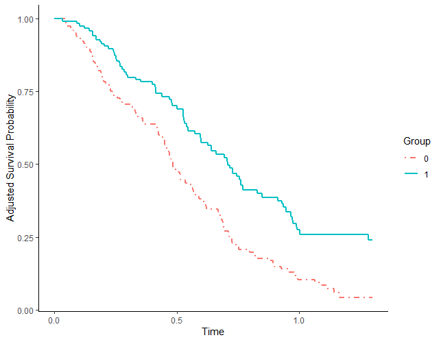

```r
plot(s_iptw, linetype=TRUE, custom_linetypes=c("dotdash", "solid"))
```

Titles and axis labels may also be changed using the respective arguments:

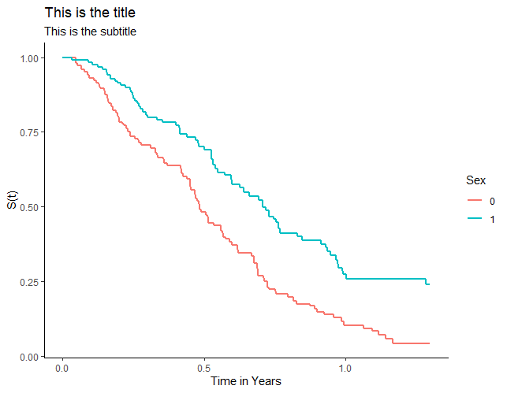

```r
plot(s_iptw, xlab="Time in Years", ylab="S(t)",
     title="This is the title", subtitle="This is the subtitle",
     legend.title="Sex")
```

# Confidence Intervals

When confidence intervals were estimated using `conf_int=TRUE` or `bootstrap=TRUE` in the original `adjustedsurv()` function call, it is of course possible to visualize them using the `plot()` method as well:

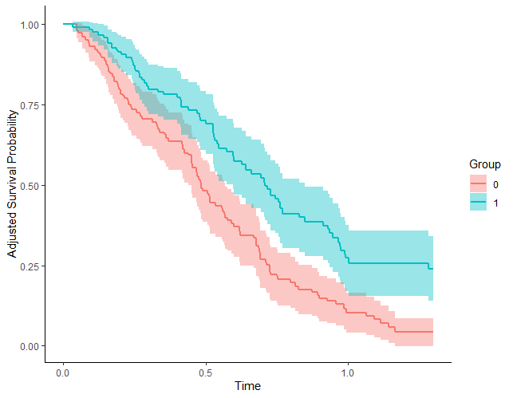

```r
plot(s_iptw, conf_int=TRUE)
```

Note that the confidence level cannot be changed here. This can only be done directly in the `adjustedsurv()` function.

# Median Survival Time Indicators

The median survival time is often used as a summary statistic and to compare different survival curves. In this package, it may be calculated using the `adjusted_surv_quantile()` function. However, it may also make sense to add some indicator lines to the plot to visually help the reader to read off the median survival time from the plot as well. This can be done using the `median_surv_lines` argument:

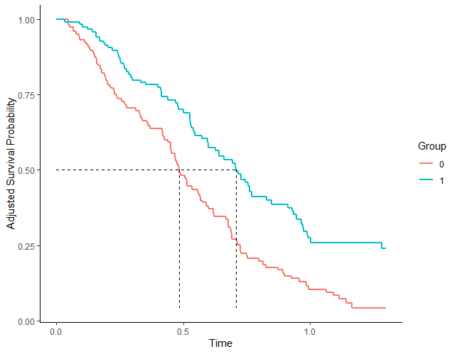

```r
plot(s_iptw, median_surv_lines=TRUE)
```

The drawn lines may also be customized. Below we make the lines thicker, change their color and change their linetype from `"dashed"` to `"dotdash"`:

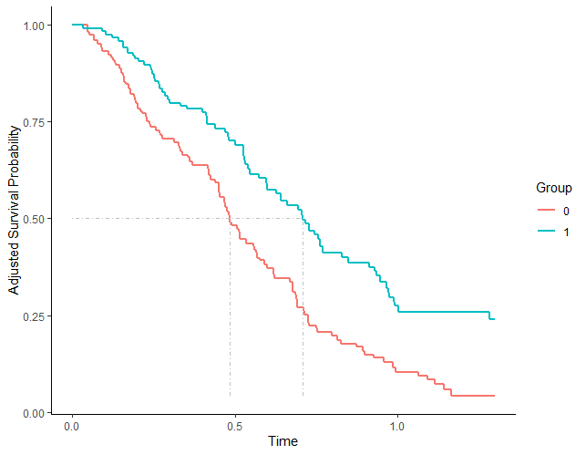

```r
plot(s_iptw, median_surv_lines=TRUE, median_surv_linetype="dotdash",
     median_surv_size=0.7, median_surv_color="grey")
```

It is also possible to use other survival time quantiles by changing the `median_surv_quantile` argument:

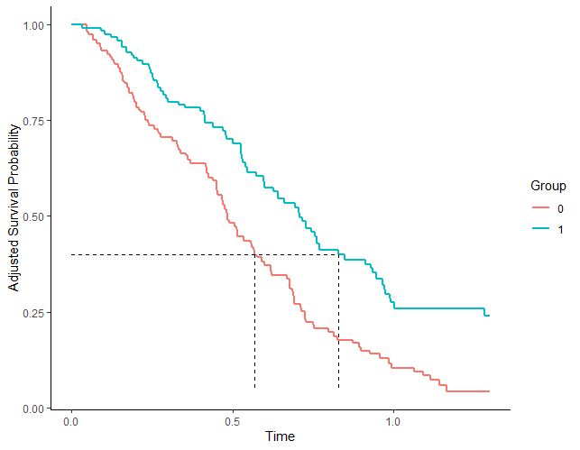

```r
plot(s_iptw, median_surv_lines=TRUE, median_surv_quantile=0.4)
```

# Censoring Indicators

In standard Kaplan-Meier plots, the timing of censored observations is often added to the plot as well. This can be done in this package as well, using the `censoring_ind` argument. We could, for example, add small vertical lines to show the censored observations:

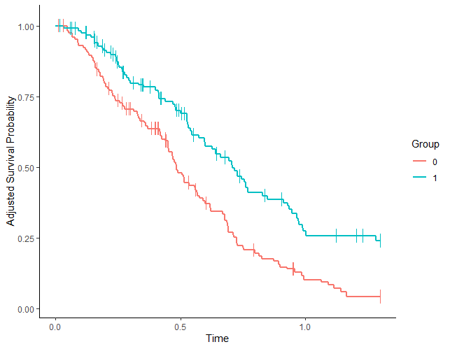

```r
plot(s_iptw, censoring_ind="lines")
```

Alternatively, points of any shape could be added as well:

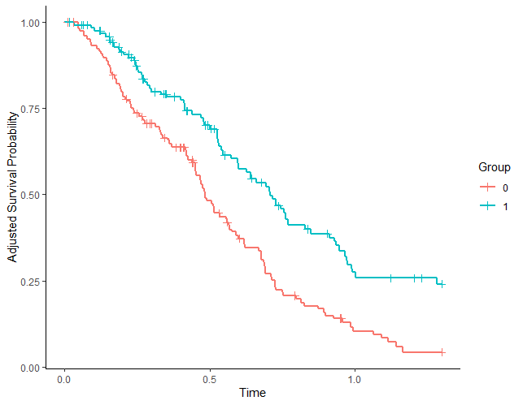

```r
plot(s_iptw, censoring_ind="points", censoring_ind_shape=3,
     censoring_ind_size=2)
```

# Risk Tables

First, let’s call the `plot()` function with the default risk table arguments:

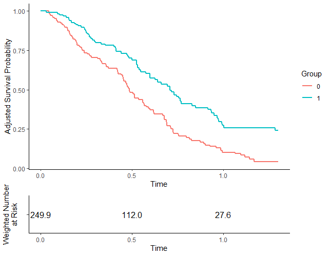

```r
plot(s_iptw, risk_table=TRUE)
```

## Changing the content of risk tables

Since we are using a weighted Kaplan-Meier estimator, the weighted number at risk is shown by default. We could use the unweighted number at risk by setting `risk_table_use_weights=FALSE`, but this wouldn’t make much sense. Instead of using the weighted number at risk, we can also use the weighted number of cumulative events:

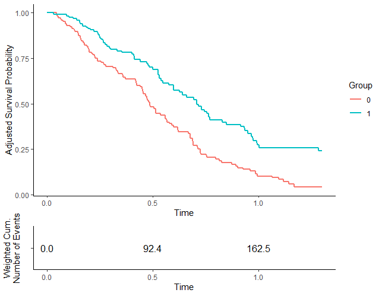

```r
plot(s_iptw, risk_table=TRUE, risk_table_type="n_events")
```

or the weighted cumulative number of censored observations:

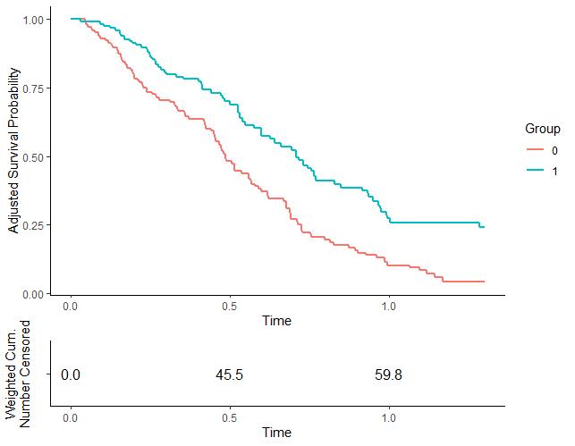

```r
plot(s_iptw, risk_table=TRUE, risk_table_type="n_cens")
```

By setting `risk_table_stratify=TRUE`, we are also able to stratify the risk table by the different levels in `variable`:

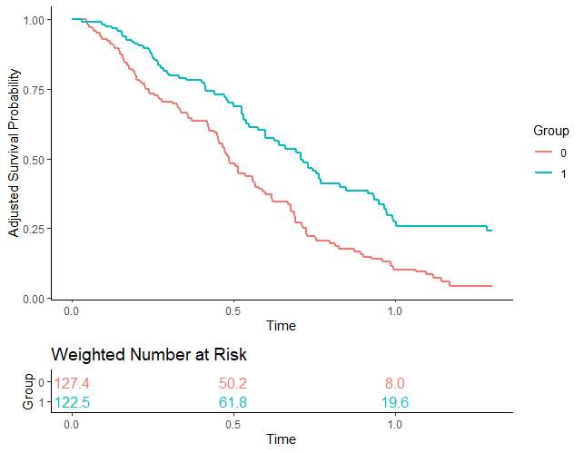

```r
plot(s_iptw, risk_table=TRUE, risk_table_stratify=TRUE)
```

Since weights are used here, there is no guarantee that the number of people at risk are integer values. By default the numbers are rounded to one digit to make this clear, but we can also set the `risk_table_digits` argument to 0 to round them to the nearest integer, which may be a little less confusing for some people:

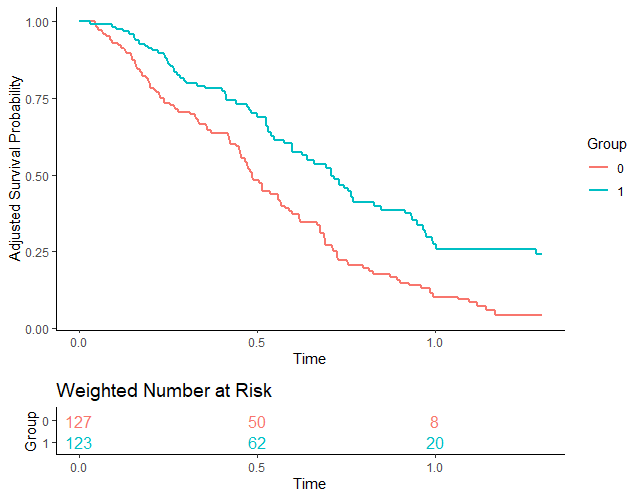

```r
plot(s_iptw, risk_table=TRUE, risk_table_stratify=TRUE,
     risk_table_digits=0)
```

The risk tables only show numbers at the break points of the x-axis shown in the survival curve plot, to make everything align nicely. To get more numbers at more points in time, we can simply augment the `x_breaks` or `x_n_breaks` arguments, like this:

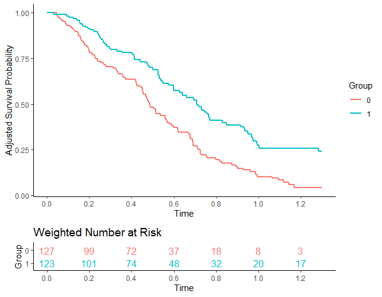

```r
plot(s_iptw, risk_table=TRUE, risk_table_stratify=TRUE,
     risk_table_digits=0, x_n_breaks=10)
```

## Changing aesthetic parameters

The size and look of the numbers may be changed as well:

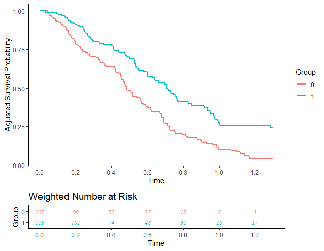

```r
plot(s_iptw, risk_table=TRUE, risk_table_stratify=TRUE,
     risk_table_digits=0, x_n_breaks=10, risk_table_size=3,
     risk_table_family="serif", risk_table_fontface="italic")
```

Additionally, users may turn off the coloring of the numbers:

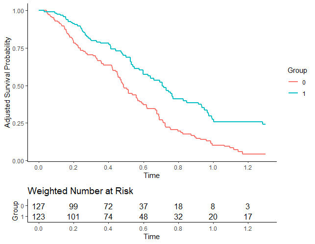

```r
plot(s_iptw, risk_table=TRUE, risk_table_stratify=TRUE,
     risk_table_digits=0, x_n_breaks=10,
     risk_table_stratify_color=FALSE)
```

Or use different colors:

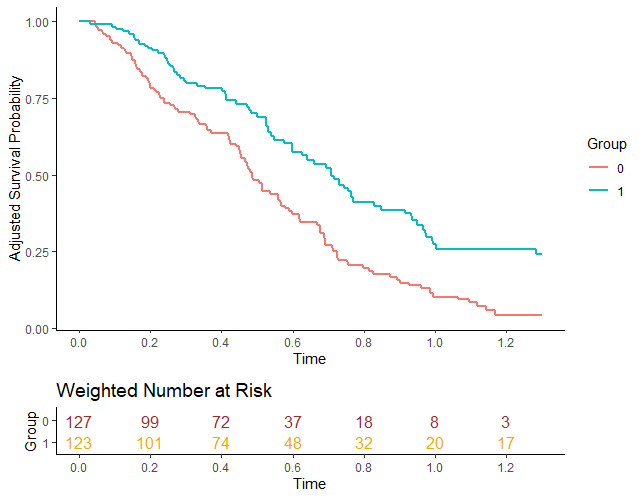

```r
plot(s_iptw, risk_table=TRUE, risk_table_stratify=TRUE,
     risk_table_digits=0, x_n_breaks=10,
     risk_table_custom_colors=c("brown", "orange"))
```

The title and axis labels may of course also be changed or removed:

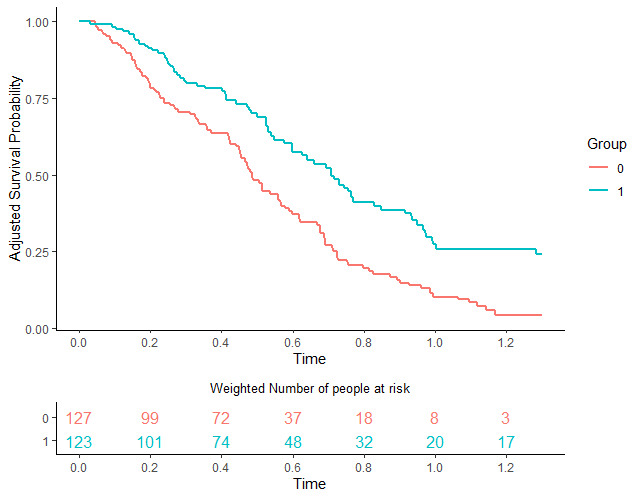

```r
plot(s_iptw, risk_table=TRUE, risk_table_stratify=TRUE,
     risk_table_digits=0, x_n_breaks=10,
     risk_table_title="Weighted Number of people at risk",
     risk_table_title_size=10, risk_table_title_position="middle",
     risk_table_ylab=NULL)
```

Internally, separate plots are created for the survival curves and for the risk table and put together afterwards using the `plot_grid()` function of the `cowplot` package. Because of this, users may also set different `ggplot2` themes for the plots:

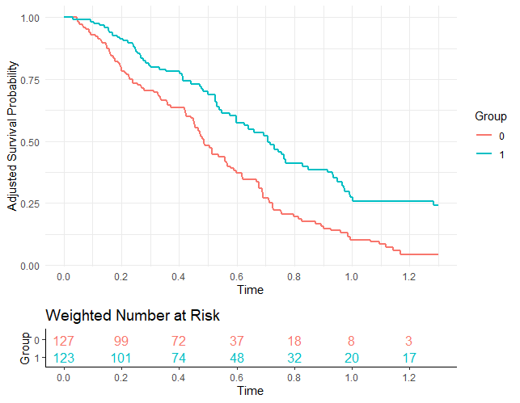

```r
plot(s_iptw, risk_table=TRUE, risk_table_stratify=TRUE,
     risk_table_digits=0, x_n_breaks=10,
     risk_table_theme=ggplot2::theme_classic(),
     gg_theme=ggplot2::theme_minimal())
```

## Additional customization options

Usually, the `plot()` function returns a standard `ggplot2` object that may be modified using standard `ggplot2` syntax. This, however, is no longer the case when using risk tables, because the output now consists of two plots that have been put together.

This means that this code works fine:

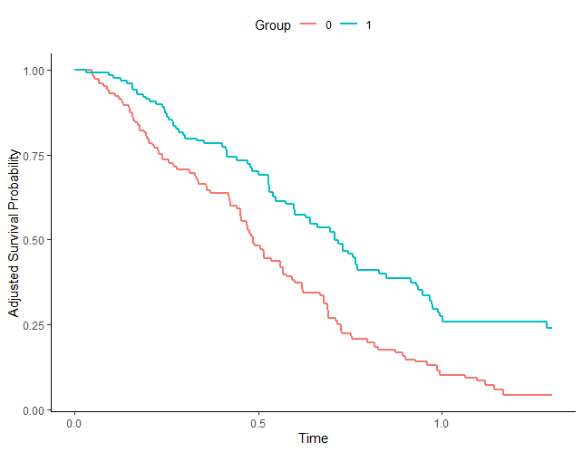

```r
# legend is successfully put at the top
plot(s_iptw) +
  theme(legend.position="top")
```

While the following code does not work:

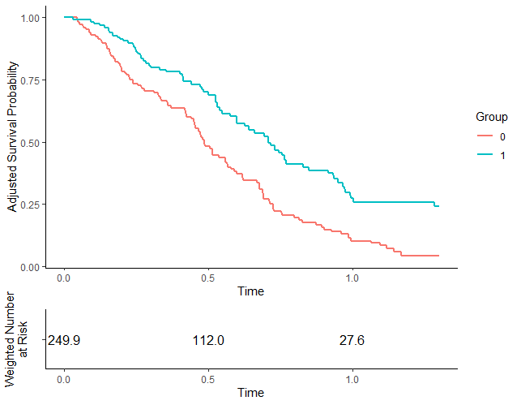

```r
# legend remains at the right side
plot(s_iptw, risk_table=TRUE) +
  theme(legend.position="top")
```

To still allow users to use all standard `ggplot2` options when using risk tables we added two additional arguments: `additional_layers` and `risk_table_additional_layers`. Users may pass a list of objects that can be added to a `ggplot2` object to either of these arguments. All objects in the list passed to `additional_layers` will be added to the survival curve plot before putting it together with the risk table plot. Similarly, all objects in the `risk_table_additional_layers` list will be applied to the risk table plot.

The preceding example could be fixed using the following code:

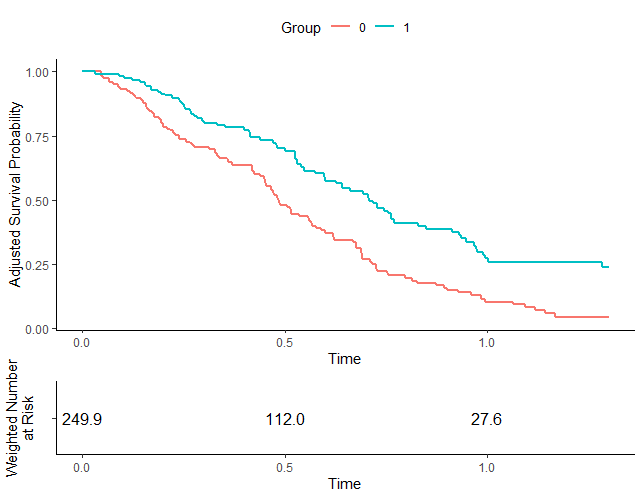

```r
more_stuff <- list(theme(legend.position="top"))
plot(s_iptw, risk_table=TRUE, additional_layers=more_stuff)
```

In this particular case, we could have also simply set the `legend.position` to top, but this of course only works for arguments directly supported by the `plot()` method. Using the arguments mentioned above, we can do quite a bit more, such as adding more geoms:

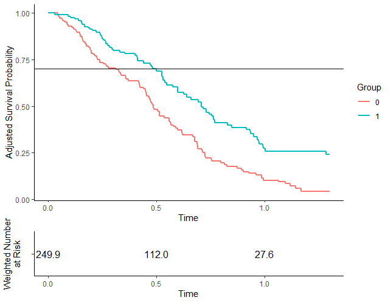

```r
more_stuff <- list(geom_hline(yintercept=0.7))
plot(s_iptw, risk_table=TRUE, additional_layers=more_stuff)
```

Which also works for the risk table subplot using the other argument:

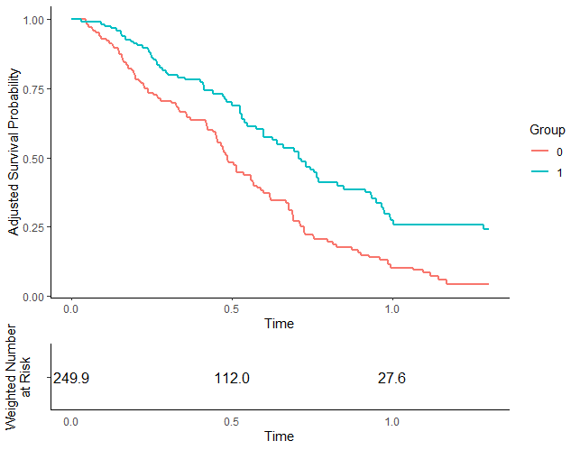

```r
# remove x-axis ticks from risk table for some reason
more_stuff <- list(theme(axis.ticks.x=element_blank()))
plot(s_iptw, risk_table=TRUE, risk_table_additional_layers=more_stuff)
```

# Putting it all together

In this particular case, we would probably use something similar to the following code to create a decent output:

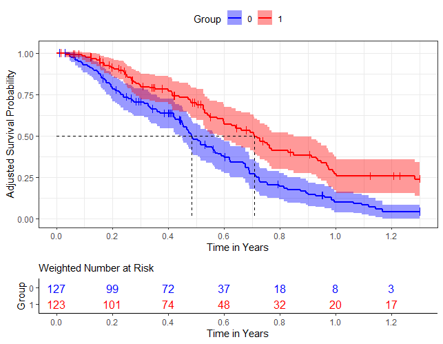

```r
plot(s_iptw, conf_int=TRUE, censoring_ind="lines", risk_table=TRUE,
     risk_table_stratify=TRUE, risk_table_digits=0, x_n_breaks=10,
     risk_table_title_size=11, median_surv_lines=TRUE,
     gg_theme=theme_bw(), risk_table_theme=theme_classic(),
     legend.position="top", custom_colors=c("blue", "red"),
     xlab="Time in Years")
```

Of course this is just one of many possibilities.